# AS3-2: 股市動態

第20組

2019-03-11 23:11:31

**股票動態**

股票市場是買賣雙方交易公司股票的地方，也是個人和公司投資的最受歡迎的方式之一。現在估計世界股票市場規模達到數兆。紐約證券交易所位於紐約市，是世界上最大的股票市場。 紐約證券交易所約有2,800家上市公司。在這個問題上，我們將看看其中五家公司的每月股價：IB、通用電氣（GE）、寶潔、可口可樂和波音。此問題中使用的數據來自Infochimps。

使用`read.csv()`下載並讀取以下文件：

- `data/IBMStock.csv`
- `data/GEStock.csv`
- `data/ProcterGambleStock.csv`
- `data/CocaColaStock.csv`
- `data/BoeingStock.csv`

分別存入資料框`IBM`、`GE`、`ProcterGamble`、`CocaCola`和`Boeing`， 每個資料框都有兩個變量，描述如下：

- `Date`：日期
- `StockPrice`：給定月份公司的平均股價

```r
IBM = read.csv("data/IBMStock.csv")
GE = read.csv("data/GEStock.csv")
PG = read.csv("data/ProcterGambleStock.csv")
CK = read.csv("data/CocaColaStock.csv")
BE = read.csv("data/BoeingStock.csv")
IBM$Date = as.Date(IBM$Date, "%m/%d/%y")
GE$Date = as.Date(GE$Date, "%m/%d/%y")
CK$Date = as.Date(CK$Date, "%m/%d/%y")
PG$Date = as.Date(PG$Date, "%m/%d/%y")
BE$Date = as.Date(BE$Date, "%m/%d/%y")
```

在這個案例，我們將看看這些公司的股票動態如何隨著時間的推移而發生變化。

### Section-1 Summary Statistics

**§ 1.1** Our five datasets all have the same number of observations. How many observations are there in each data set?

```r
nrow(IBM)
```

```
[1] 480
```

**§ 1.2** What is the earliest year in our datasets?

```r
min(IBM$Date)
```

```
[1] "1970-01-01"
```

**§ 1.3** What is the latest year in our datasets?

```r
max(IBM$Date)
```

```
[1] "2009-12-01"
```

**§ 1.4** What is the mean stock price of IBM over this time period?

```r
mean(IBM$StockPrice)
```

```
[1] 144.4
```

**§ 1.5** What is the minimum stock price of General Electric (GE) over this time period?

```r
min(GE$StockPrice)
```

```
[1] 9.294
```

**§ 1.6** What is the maximum stock price of Coca-Cola over this time period?

```r
max(CK$StockPrice)
```

```
[1] 146.6
```

**§ 1.7** What is the median stock price of Boeing over this time period?

```r
median(BE$StockPrice)
```

```
[1] 44.88
```

**§ 1.8** What is the standard deviation of the stock price of Procter & Gamble over this time period?

```r
sd(PG$StockPrice)
```

```
[1] 18.19
```

### Section-2 Visualizing Stock Dynamics

**§ 2.1** Around what year did Coca-Cola has its highest stock price in this time period? Around what year did Coca-Cola has its lowest stock price in this time period?

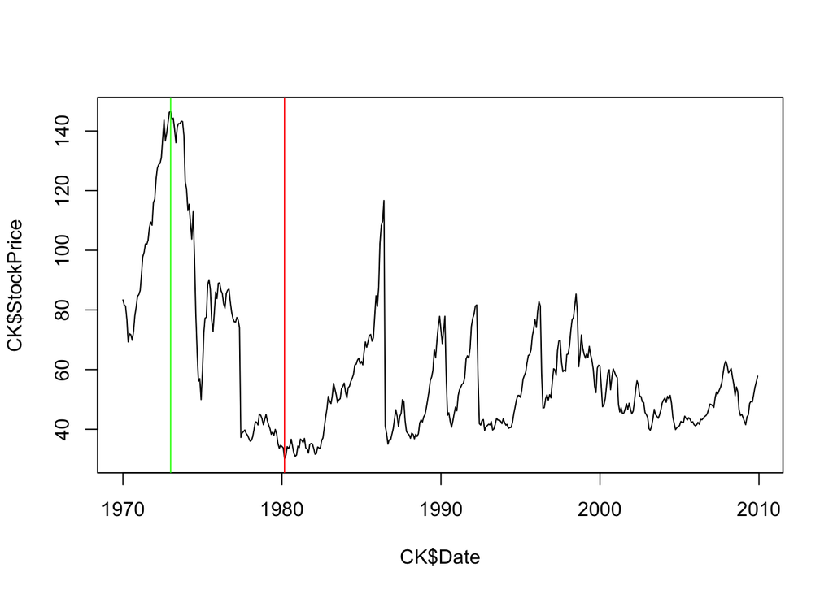

```r
plot(CK$Date, CK$StockPrice, type='l')
abline(v=CK$Date[which.max(CK$StockPrice)], col='green')
abline(v=CK$Date[which.min(CK$StockPrice)], col='red')
```

**§ 2.2** In March of 2000, the technology bubble burst, and a stock market crash occurred. According to this plot, which company’s stock dropped more?

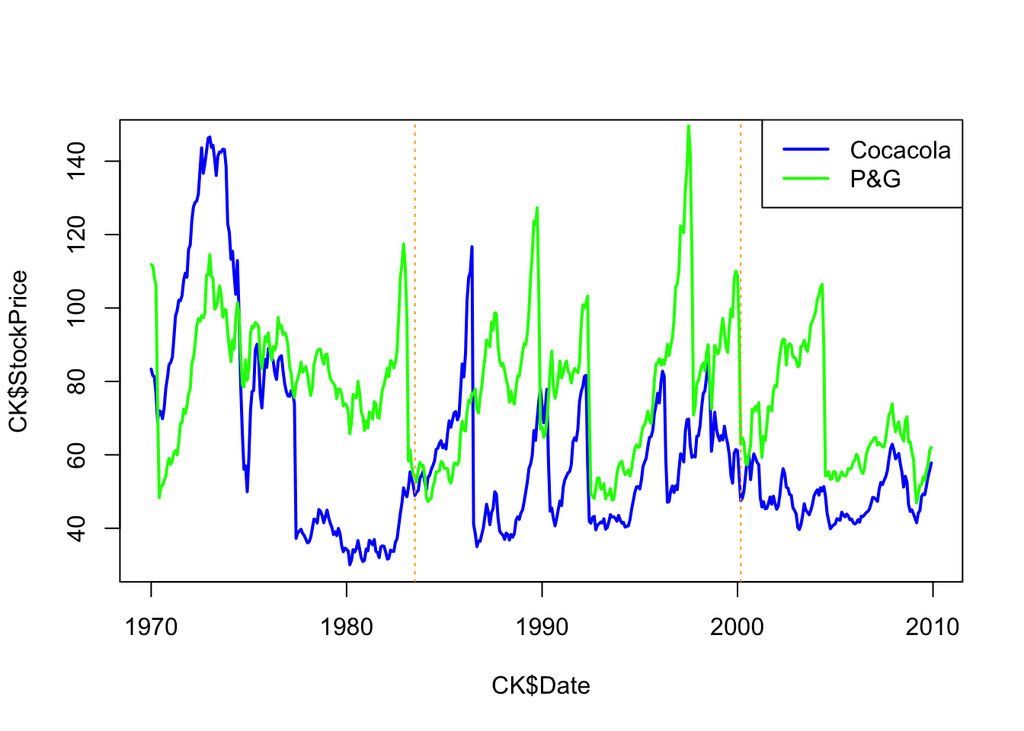

```r
plot(CK$Date, CK$StockPrice, type='l', col='blue', lwd=2)
lines(PG$Date, PG$StockPrice, col="green", lwd=2)
abline(v = as.Date("2000-03-01"), lty=3, col='orange')
abline(v = as.Date("1983-07-01"), lty=3, col='orange')
legend("topright",legend=c("Cocacola","P&G"),col=c('blue','green'),lwd=2)
```

```r
#P&G
```

**§ 2.3** (a) Around 1983, the stock for one of these companies (Coca-Cola or Procter and Gamble) was going up, while the other was going down. Which one was going up?

```r
# Coca-Cola
```

2. In the time period shown in the plot, which stock generally has lower values?

```r
#Coca-Cola
```